# Assignment 1

### d)

**No it seems the old location is better for production over the new one with the mean and median being higher at the old location**

### e)

```r
mean(vto)
```

```
## [1] 9.803667
```

```r
median(vto)
```

```
## [1] 9.975
```

```r
getmode(vto)
```

```
## [1] 9.98
```

```r
mean(vtn)
```

```
## [1] 9.422333
```

```r
median(vtn)
```

```
## [1] 9.455
```

```r
getmode(vtn)
```

```
## [1] 8.82
```

### f)

```r
(10.5-mean(vto))/sd(vto)
```

```
## [1] 1.287324
```

### g)

```r
(10.5-mean(vtn))/sd(vtn)
```

```
## [1] 2.25041
```

### h)

**A voltage of 10.5 is more likely to happen in the old location as it is 1.29 standard deviations from the mean of the data**

### i)

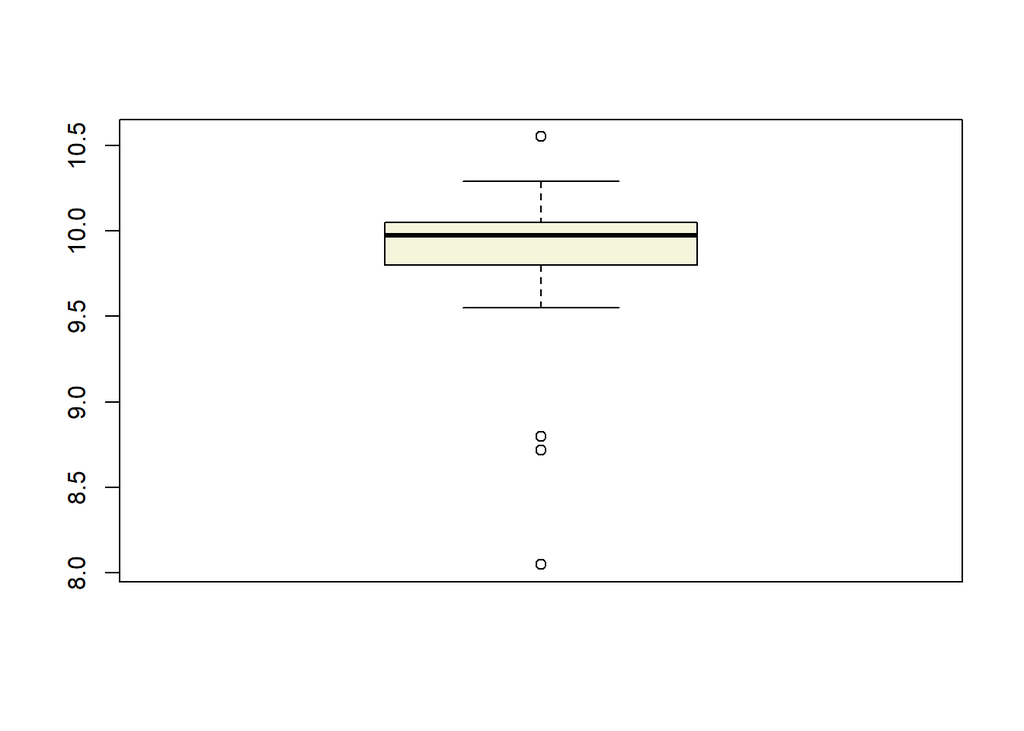

```r
boxplot(vto, col="BEIGE")
```

### j)

```r
z=(vto-mean(vto))/sd(vto)
z[abs(z)>=2 & abs(z)<=3]
```

```
## [1] -2.003394 -2.003394
```

```r
vto[abs(z)>=2 & abs(z)<=3]
```

```
## [1] 8.72 8.72
```

### k)

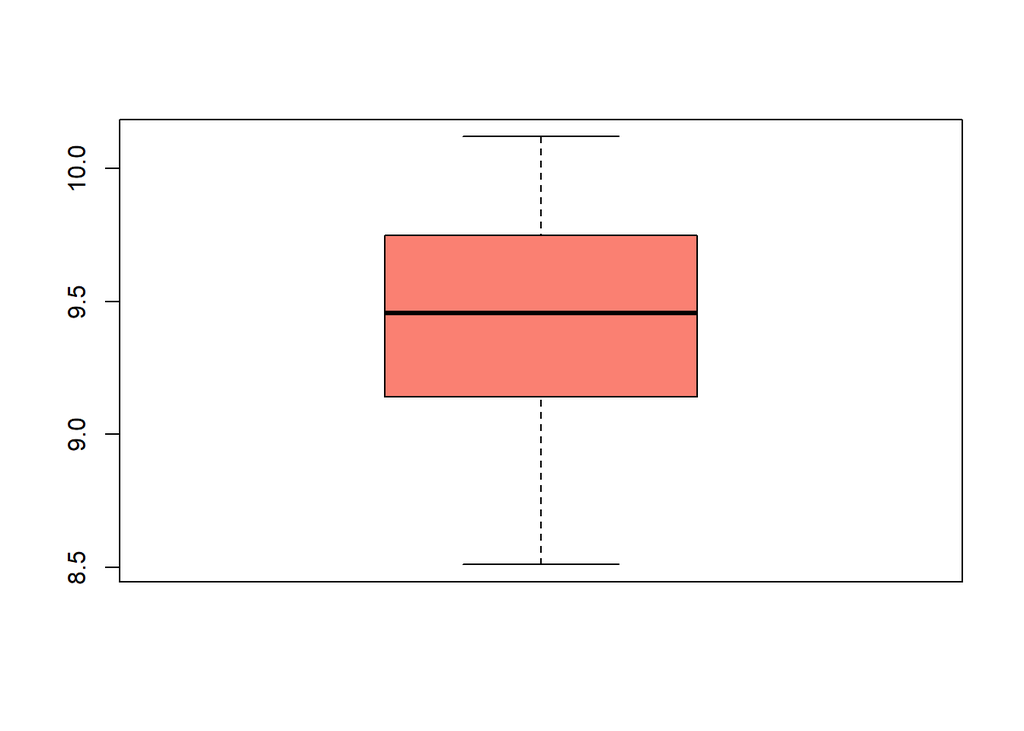

```r
boxplot(vtn, col="SALMON")
```

### l)

```r
z=(vtn-mean(vtn))/sd(vtn)
z[abs(z)>=2 & abs(z)<=3]
```

```
## numeric(0)
```

```r
vtn[abs(z)>=2 & abs(z)<=3]
```

```
## numeric(0)
```

### m)

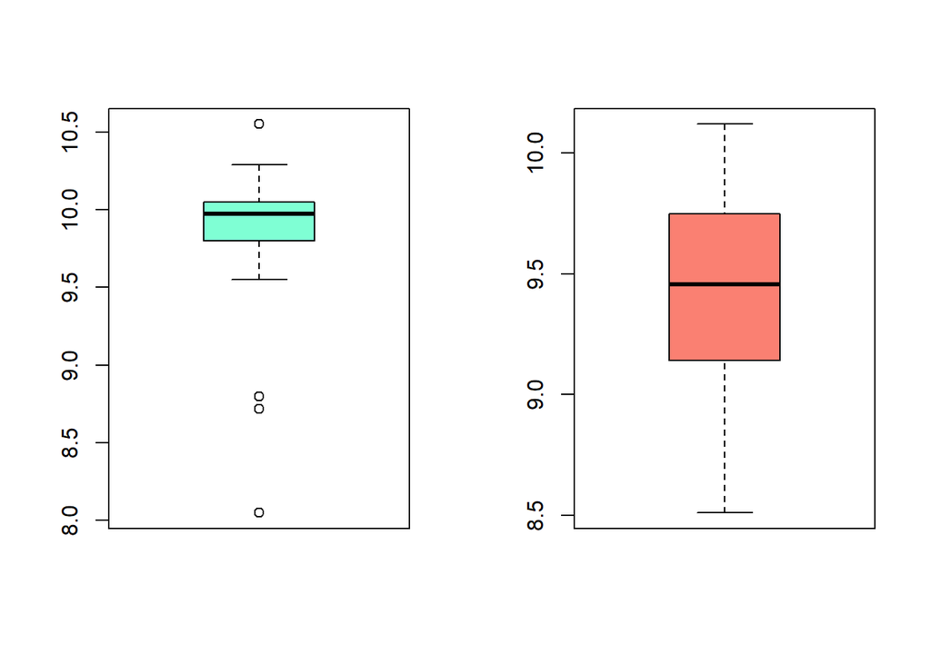

```r
layout(matrix(1:2,nr=1,nc=2))
boxplot(vto, col="AQUAMARINE")
boxplot(vtn, col="SALMON")
```

# Problem 12

```r
pipe=read.csv("ROUGHPIPE.csv")
head(pipe)
```

```
##   ROUGH
## 1  1.72
## 2  2.57
## 3  2.50
## 4  2.64
## 5  2.16
## 6  1.26
```

```r
r=pipe$ROUGH

#Standardize(transform) into z values
z=(r-mean(r))/sd(r)

#class
class(z)
```

```
## [1] "numeric"
```

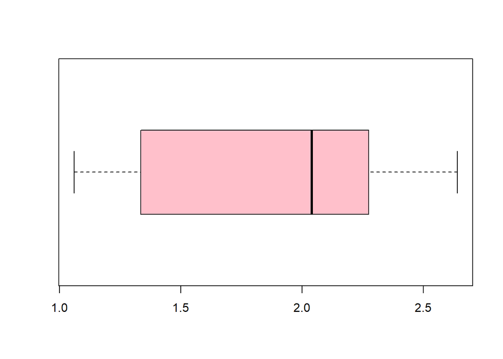

```r
boxplot(r[abs(z)<3], col="PINK", horizontal=TRUE)
```

# Problem 13

```r
ant=read.csv("GOBIANTS.csv")
head(ant)
```

```
##   Site      Region Rain Temp PlantCov AntSpecies Diversity
## 1    1 Dry Steppe   196  5.7       40          3      0.89
## 2    2 Dry Steppe   196  5.7       52          3      0.83
## 3    3 Dry Steppe   179  7.0       40         52      1.31
## 4    4 Dry Steppe   197  8.0       43          7      1.48
## 5    5 Dry Steppe   149  8.5       27          5      0.97
## 6    6 Gobi Desert  112 10.7       30         49      0.46
```

### a)

```r
ants= ant$AntSpecies
mean(ants)
```

```
## [1] 12.81818
```

```r
median(ants)
```

```
## [1] 5
```

```r
getmode(ants)
```

```
## [1] 5
```

### c)

```r
dryplants<-subset(ant,subset=Region=="Dry Steppe")
dryplants.v=dryplants$PlantCov
mean(dryplants.v)
```

```
## [1] NaN
```

```r
median(dryplants.v)
```

```
## [1] NA
```

```r
getmode(dryplants.v)
```

```
## [1] NA
```

### d)

```r
desertplants<-subset(ant,subset=Region=="Gobi Desert")
desertplant.v = desertplants$PlantCov
mean(desertplant.v)
```

```
## [1] 28
```

```r
median(desertplant.v)
```

```
## [1] 26
```

```r
getmode(desertplant.v)
```

```
## [1] 30
```

### e)

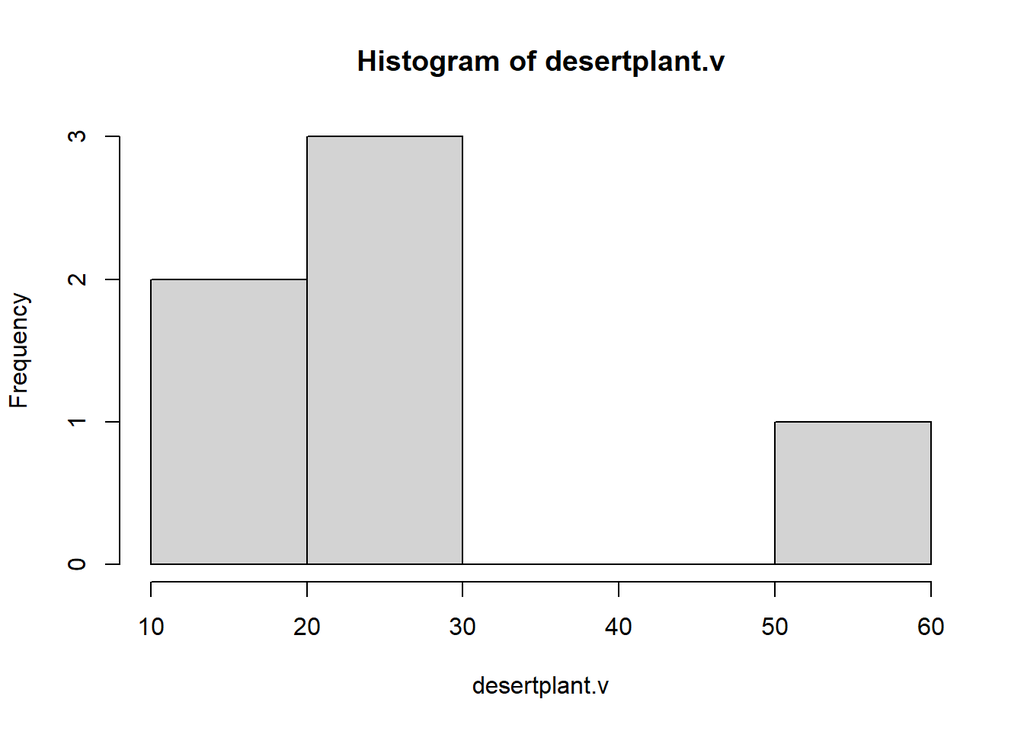

```r
hdep<-hist(desertplant.v)
```

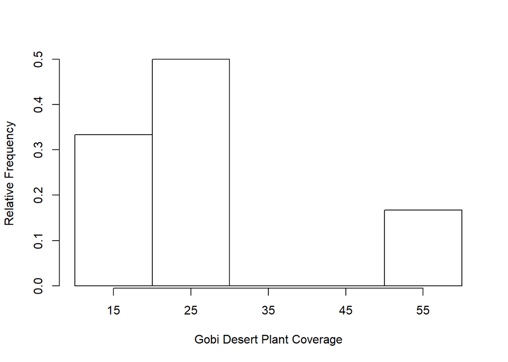

```r
n=length(desertplant.v)
barplot(hdep$counts/n,col="white",space=0)->bp
axis(1,at=c(bp),labels=hdep$mids)
title(ylab="Relative Frequency",xlab="Gobi Desert Plant Coverage")
```

```r
#dryplants wont plot because invalid number of breaks
```

# Problem 14

```r
galaxy=read.csv("GALAXY2.csv")
head(galaxy)
```

```
##   VELOCITY
## 1    22922
## 2    20210
## 3    21911
## 4    19225
## 5    18792
## 6    21993
```

### a)

```r
vel<-galaxy$VELOCITY
max(vel)
```

```
## [1] 24909
```

```r
min(vel)
```

```
## [1] 18499
```

```r
lept<-min(vel)-0.05
rept<-max(vel)+0.05
rnge<-rept-lept
inc<-rnge/9
inc
```

```
## [1] 712.2333
```

```r
seq(lept, rept,by=inc)->cl
cl
```

```
##  [1] 18498.95 19211.18 19923.42 20635.65 21347.88 22060.12 22772.35 23484.58
##  [9] 24196.82 24909.05
```

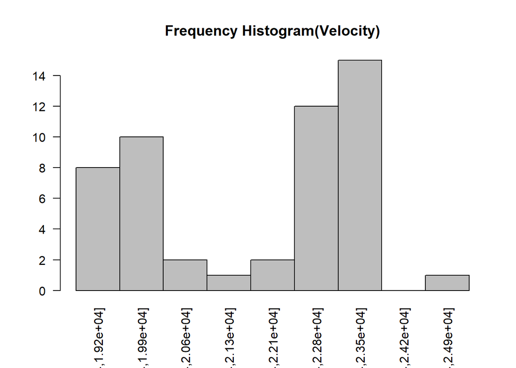

```r
cvel<-cut(vel,breaks=cl)
new.tab=table(cvel)
barplot(new.tab,space=0,main="Frequency Histogram(Velocity)",las=2)
```

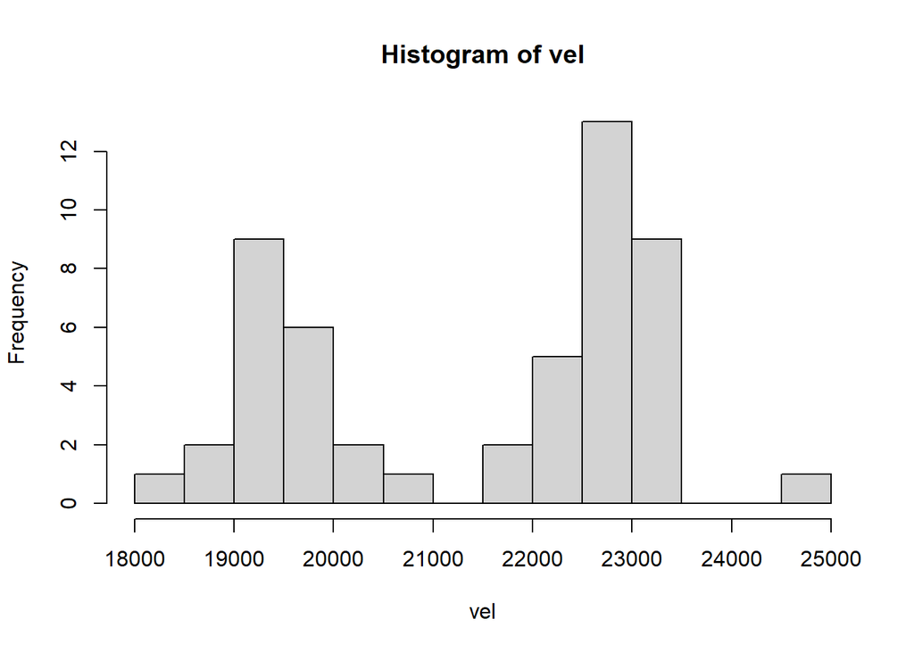

```r
hist(vel,nclass=10)
```

### b)

**Yes on the second graph there are two major peaks in the graph**

# Problem 15

```r
library(dplyr)
```

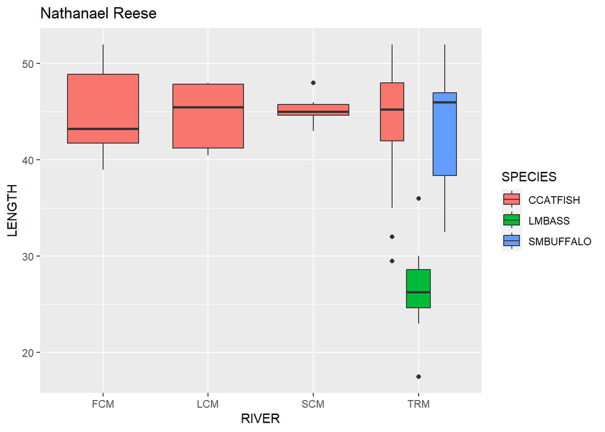

```r
library(ggplot2)
ddt%>%filter(WEIGHT > 100)%>%ggplot(aes(x=RIVER,y=LENGTH,fill=SPECIES))+geom_boxplot()+ggtitle("Nathanael Reese")
```